# Multi-linear regression.

2. Run diagnostics on the final 5-predictor model you selected. Include appropriate residual plots and your comments on the quality and usefulness of the fit. (Make your own codeboxes and comment boxes.)

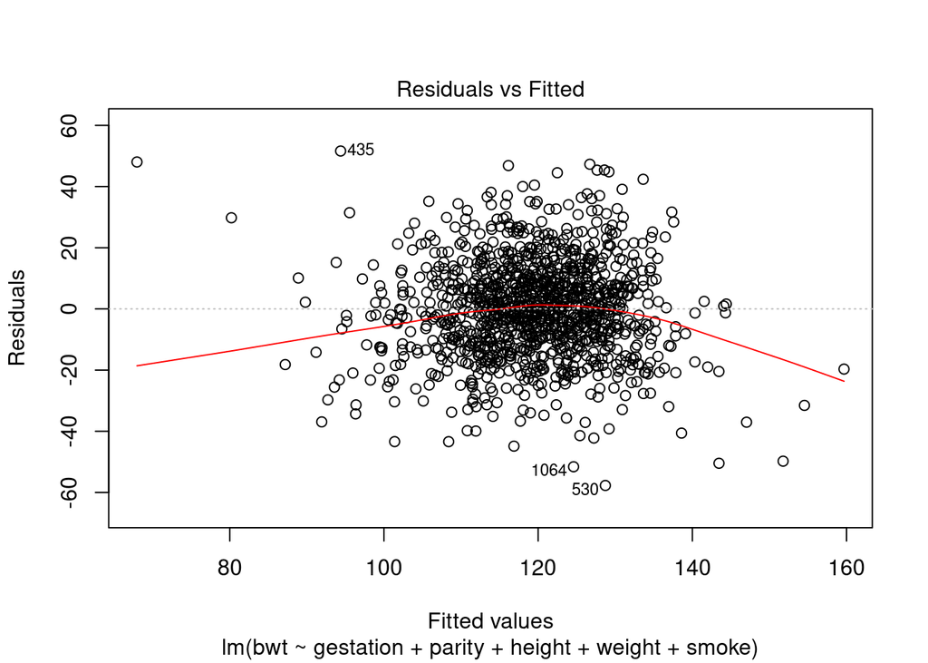

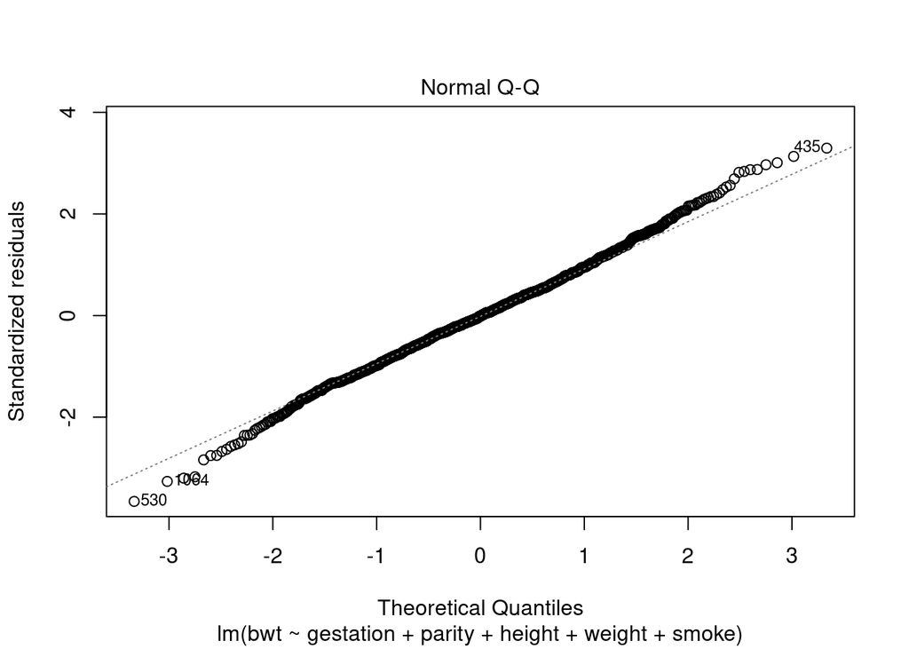

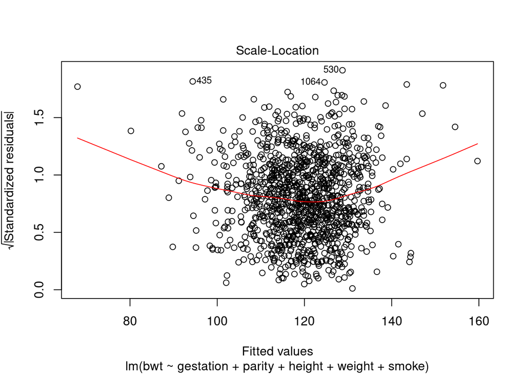

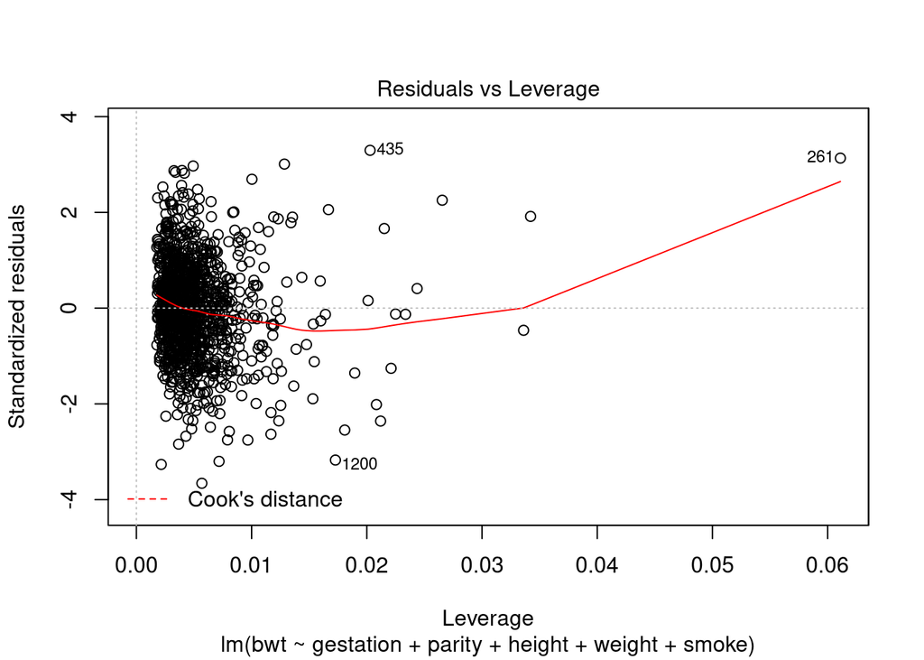

[output not shown]

```r
plot(partial5.lm)
```

3. In the plots you created before doing any regressions, there were apparent outliers with regard to both X1 and X4. Without doing the work, say what steps you would take to evaluate whether we should consider removing these outliers. (Your own comment box.)

```
Remove the outliers, recreate the linear model, then check change the t-values for both predictors, along with the adjusted R-squared value. If the change is significant with removal of insignificant amount of outliers, the changes should stay.
```

4. Using `Forward Addition`, choose a “best” multilinear model for this data set. Begin by choosing the single predictor that gives the highest value of Adjusted R-squared and continue by adding variables until Adjusted R-squared has been maximized. *Your answer should consist of a set of nested models with increasing Adjusted R-squared*

```r
X1.lm = lm(bwt ~ gestation, data = babies)
X1X6.lm = lm(bwt ~ gestation + smoke, data = babies)
X1X6X4.lm = lm(bwt ~ gestation + smoke + height, data = babies)
X1X6X4X2.lm = lm(bwt ~ gestation + smoke + height + parity, data = babies)
X1X6X4X2X5.lm = lm(bwt ~ gestation + smoke + height + parity + weight, data = babies)
X1X6X4X2X5X3.lm = lm(bwt ~ gestation + smoke + height + parity + weight + age, data = babies)
summary(X1.lm)
```

```
##
## Call:
## lm(formula = bwt ~ gestation, data = babies)
##
## Residuals:
##     Min      1Q  Median      3Q     Max
## -49.348 -11.065   0.218  10.101  57.704
##
## Coefficients:
##              Estimate Std. Error t value Pr(>|t|)
## (Intercept) -10.75414    8.53693   -1.26    0.208
## gestation     0.46656    0.03054   15.28   <2e-16 ***
## ---
## Signif. codes:  0 '***' 0.001 '**' 0.01 '*' 0.05 '.' 0.1 ' ' 1
##
## Residual standard error: 16.74 on 1172 degrees of freedom
## Multiple R-squared:  0.1661, Adjusted R-squared:  0.1654
## F-statistic: 233.4 on 1 and 1172 DF,  p-value: < 2.2e-16
```

```r
summary(X1X6.lm)
```

```
##
## Call:
## lm(formula = bwt ~ gestation + smoke, data = babies)
##
## Residuals:
##     Min      1Q  Median      3Q     Max
## -50.789 -11.035  -0.211  10.053  52.412
##
## Coefficients:
##             Estimate Std. Error t value Pr(>|t|)
## (Intercept) -3.18492    8.32945  -0.382    0.702
## gestation    0.45117    0.02968  15.200   <2e-16 ***
## smoke       -8.37440    0.97346  -8.603   <2e-16 ***
## ---
## Signif. codes:  0 '***' 0.001 '**' 0.01 '*' 0.05 '.' 0.1 ' ' 1
##
## Residual standard error: 16.25 on 1171 degrees of freedom
## Multiple R-squared:  0.2157, Adjusted R-squared:  0.2143
## F-statistic:   161 on 2 and 1171 DF,  p-value: < 2.2e-16
```

```r
summary(X1X6X4.lm)
```

```
##
## Call:
## lm(formula = bwt ~ gestation + smoke + height, data = babies)
##
## Residuals:
##     Min      1Q  Median      3Q     Max
## -57.373 -10.365  -0.450   9.853  53.250
##
## Coefficients:
##              Estimate Std. Error t value Pr(>|t|)
## (Intercept) -83.01125   13.87372  -5.983 2.90e-09 ***
## gestation     0.43631    0.02915  14.969  < 2e-16 ***
## smoke        -8.52262    0.95370  -8.936  < 2e-16 ***
## height        1.31198    0.18443   7.114 1.96e-12 ***
## ---
## Signif. codes:  0 '***' 0.001 '**' 0.01 '*' 0.05 '.' 0.1 ' ' 1
##
## Residual standard error: 15.91 on 1170 degrees of freedom
## Multiple R-squared:  0.2482, Adjusted R-squared:  0.2463
## F-statistic: 128.7 on 3 and 1170 DF,  p-value: < 2.2e-16
```

```r
summary(X1X6X4X2.lm)
```

```
##
## Call:
## lm(formula = bwt ~ gestation + smoke + height + parity, data = babies)
##
## Residuals:
##     Min      1Q  Median      3Q     Max
## -58.415 -10.173  -0.094   9.835  52.711
##
## Coefficients:
##              Estimate Std. Error t value Pr(>|t|)
## (Intercept) -85.71342   13.83578  -6.195 8.06e-10 ***
## gestation     0.44393    0.02911  15.252  < 2e-16 ***
## smoke        -8.54051    0.94951  -8.995  < 2e-16 ***
## height        1.33565    0.18375   7.269 6.62e-13 ***
## parity       -3.56015    1.05529  -3.374 0.000766 ***
## ---
## Signif. codes:  0 '***' 0.001 '**' 0.01 '*' 0.05 '.' 0.1 ' ' 1
##
## Residual standard error: 15.84 on 1169 degrees of freedom
## Multiple R-squared:  0.2554, Adjusted R-squared:  0.2529
## F-statistic: 100.3 on 4 and 1169 DF,  p-value: < 2.2e-16
```

```r
summary(X1X6X4X2X5.lm)
```

```
##
## Call:
## lm(formula = bwt ~ gestation + smoke + height + parity + weight,
##     data = babies)
##
## Residuals:
##     Min      1Q  Median      3Q     Max
## -57.716 -10.150  -0.159   9.689  51.620
##
## Coefficients:
##              Estimate Std. Error t value Pr(>|t|)
## (Intercept) -80.71321   14.04465  -5.747 1.16e-08 ***
## gestation     0.44408    0.02907  15.276  < 2e-16 ***
## smoke        -8.39390    0.95117  -8.825  < 2e-16 ***
## height        1.15497    0.20473   5.641 2.11e-08 ***
## parity       -3.28762    1.06281  -3.093  0.00203 **
## weight        0.04983    0.02503   1.991  0.04672 *
## ---
## Signif. codes:  0 '***' 0.001 '**' 0.01 '*' 0.05 '.' 0.1 ' ' 1
##
## Residual standard error: 15.82 on 1168 degrees of freedom
## Multiple R-squared:  0.2579, Adjusted R-squared:  0.2548
## F-statistic:  81.2 on 5 and 1168 DF,  p-value: < 2.2e-16
```

5. For the sequence of nested models above, conduct an ANOVA test comparing each model to the previous, reduced model to see if the new coefficient is statistically different from zero compared to the reduced model. Show the code for each test and state the results.

```r
anova(X1.lm, X1X6.lm)
```

```
## Analysis of Variance Table
##
## Model 1: bwt ~ gestation
## Model 2: bwt ~ gestation + smoke
##   Res.Df    RSS Df Sum of Sq      F    Pr(>F)
## 1   1172 328608
## 2   1171 309075  1     19533 74.007 < 2.2e-16 ***
## ---
## Signif. codes:  0 '***' 0.001 '**' 0.01 '*' 0.05 '.' 0.1 ' ' 1
```

```r
anova(X1X6.lm, X1X6X4.lm)
```

```
## Analysis of Variance Table
##
## Model 1: bwt ~ gestation + smoke
## Model 2: bwt ~ gestation + smoke + height
##   Res.Df    RSS Df Sum of Sq      F    Pr(>F)
## 1   1171 309075
## 2   1170 296261  1     12814 50.605 1.963e-12 ***
## ---
## Signif. codes:  0 '***' 0.001 '**' 0.01 '*' 0.05 '.' 0.1 ' ' 1
```

```r
anova(X1X6X4.lm, X1X6X4X2.lm)
```

```
## Analysis of Variance Table
##
## Model 1: bwt ~ gestation + smoke + height
## Model 2: bwt ~ gestation + smoke + height + parity
##   Res.Df    RSS Df Sum of Sq      F    Pr(>F)
## 1   1170 296261
## 2   1169 293404  1    2856.6 11.381 0.0007662 ***
## ---
## Signif. codes:  0 '***' 0.001 '**' 0.01 '*' 0.05 '.' 0.1 ' ' 1
```

```r
anova(X1X6X4X2.lm, X1X6X4X2X5.lm)
```

```
## Analysis of Variance Table
##
## Model 1: bwt ~ gestation + smoke + height + parity
## Model 2: bwt ~ gestation + smoke + height + parity + weight
##   Res.Df    RSS Df Sum of Sq      F  Pr(>F)
## 1   1169 293404
## 2   1168 292412  1    992.37 3.9639 0.04672 *
## ---
## Signif. codes:  0 '***' 0.001 '**' 0.01 '*' 0.05 '.' 0.1 ' ' 1
```

```r
# The final coefficient is only just significant, based on the P-value, and we should consider not including in in the model
```